# *Projet :*

### 3-3:Répartition selon l’age:

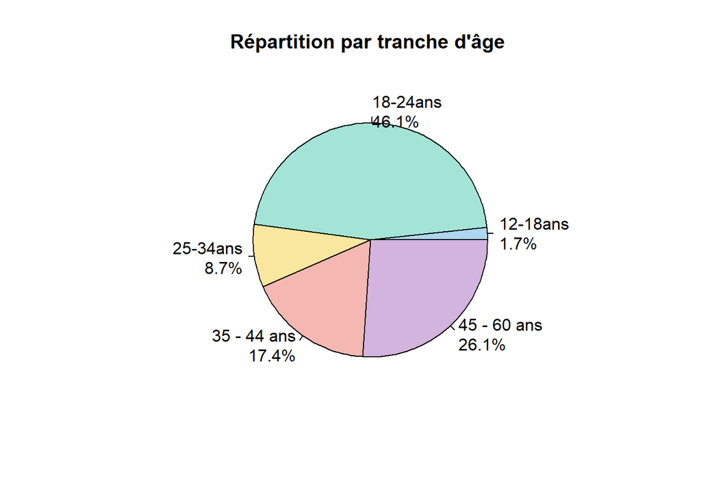

```r
# Table de fréquences
age_table <- table(donnees$classe.d.âge)
age_percent <- round(100 * age_table / sum(age_table), 1)
labels <- paste(names(age_table), "\n", age_percent, "%", sep="")

# Palette pastel personnalisée
pastel_colors <- c("#AED6F1", "#A3E4D7", "#F9E79F", "#F5B7B1", "#D2B4DE", "#FADBD8", "#A9DFBF")

# Afficher le pie chart avec couleurs pastel
pie(age_table,
    labels = labels,
    col = pastel_colors[1:length(age_table)],
    main = "Répartition par tranche d'âge ")
```

###3-3:Les catégories socio-professionnelles de l’échantillon:

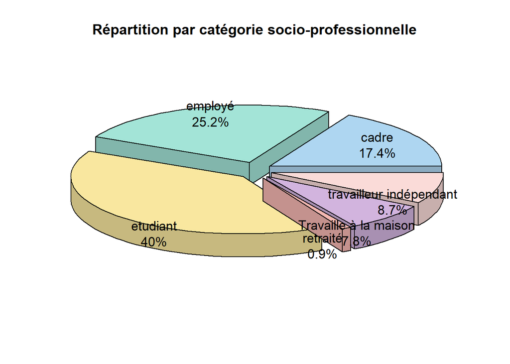

```r
library(plotrix)
# Table de fréquences
csp_table <- table(donnees$Catégorie.socio.professionnelle..CSP...)
csp_percent <- round(100 * csp_table / sum(csp_table), 1)
labels <- paste(names(csp_table), "\n", csp_percent, "%", sep="")

# Couleurs pastel
pastel_colors <- c("#AED6F1", "#A3E4D7", "#F9E79F", "#F5B7B1", "#D2B4DE", "#FADBD8", "#A9DFBF")

# Camembert 3D plus grand, plus espacé
pie3D(csp_table,
      labels = labels,
      explode = 0.15,            # éloigne davantage les parts (0.15 au lieu de 0.1)
      radius = 1.5,              # augmente la taille du cercle
      labelcex = 1.1,            # taille des étiquettes légèrement augmentée
      col = pastel_colors[1:length(csp_table)],
      main = "Répartition par catégorie socio-professionnelle")
```

### 3-4: impact des facteurs psychologiques sur le travail:

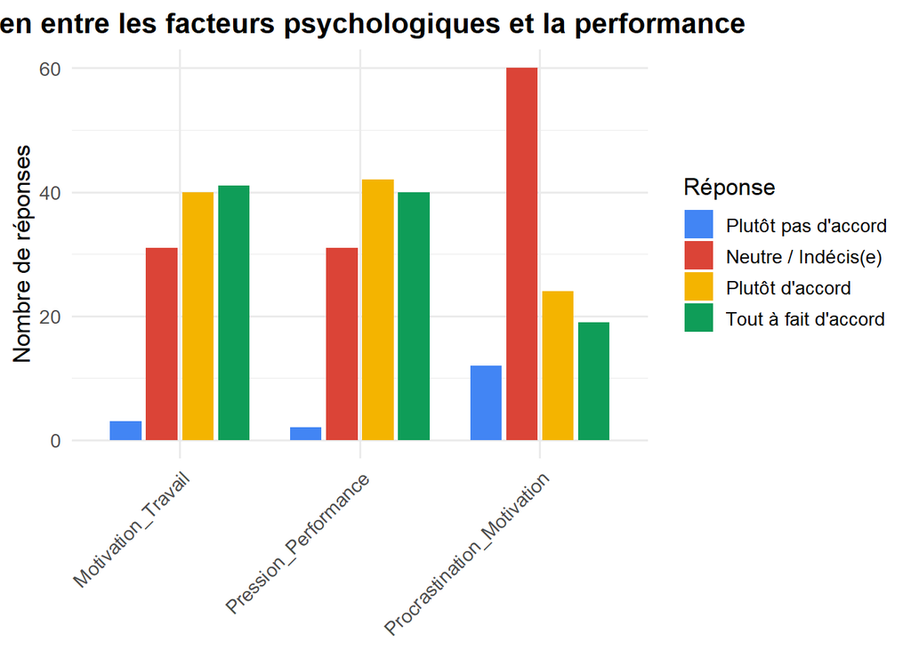

```r
# Charger la bibliothèque
library(tidyverse)

# Spécifie les colonnes à visualiser
cols_to_plot <- c(
  "Procrastination_Motivation",
  "Motivation_Travail",
  "Pression_Performance"
)

# Mettre au format long
data_long <- donnees %>%
  select(all_of(cols_to_plot)) %>%  # Sélectionne les colonnes spécifiées
  pivot_longer(cols = everything(), names_to = "Question", values_to = "Réponse") %>%
  filter(!is.na(Réponse)) %>%
  mutate(
    Réponse = factor(Réponse, levels = c(1, 2, 3, 4, 5),
                     labels = c("pas du tout d'accord",
                                "Plutôt pas d'accord",
                                "Neutre / Indécis(e)",
                                "Plutôt d'accord",
                                "Tout à fait d'accord"))
  )

# Créer le barplot groupé (côte à côte)
ggplot(data_long, aes(x = Question, fill = Réponse)) +
  geom_bar(position = position_dodge(width = 0.8), aes(y = ..count..), width = 0.7) +
  labs(
    title = "Lien entre les facteurs psychologiques et la performance",
    x = NULL,
    y = "Nombre de réponses",
    fill = "Réponse"
  ) +
  scale_fill_manual(values = c("#4285F4", "#DB4437", "#F4B400", "#0F9D58", "#9C27B0")) +
  theme_minimal(base_size = 13) +
  theme(
    axis.text.x = element_text(angle = 45, hjust = 1),
    plot.title = element_text(face = "bold", hjust = 0.5)
  )
```

## 4-Analyse en composantes principales (ACP):

### 4.1- But de l’ACP:

L’ACP permet de décrire un jeu de données, de le résumer, d’en réduire la dimensionnalité.

L’ACP vise à identifier les principaux facteurs psychologiques et sociaux influençant la productivité et la réussite, puis à regrouper les variables selon leur importance.

```r
library(FactoMineR)
```

## 4.2 ACP1

Sélectionner les colonnes numériques pour l’ACP pour Facteurs psychologiques et productivité:

```r
donnees_num <- donnees[, 5:16]
donnees_num <- na.omit(donnees_num)  # Supprimer les lignes avec NA
```

### 4.2.1-Réaliser l’ACP:

```r
res.pca <- PCA(donnees_num, scale.unit = TRUE, graph = FALSE)
```

### 4.2.2- Les axes à conserver

On utilise les critères du taux d’inertie cumulée, de Kaiser, et du coude :

```
##          eigenvalue variance.percent cumulative.variance.percent
## Dim.1  5.827023e+00     4.855852e+01                    48.55852
## Dim.2  4.968783e+00     4.140652e+01                    89.96504
## Dim.3  9.635672e-01     8.029726e+00                    97.99477
## Dim.4  1.803986e-01     1.503322e+00                    99.49809
## Dim.5  6.022888e-02     5.019073e-01                   100.00000
## Dim.6  1.181348e-30     9.844563e-30                   100.00000
## Dim.7  3.711519e-32     3.092932e-31                   100.00000
## Dim.8  9.818518e-33     8.182098e-32                   100.00000
## Dim.9  1.128915e-33     9.407626e-33                   100.00000
## Dim.10 9.095922e-34     7.579935e-33                   100.00000
## Dim.11 4.843691e-37     4.036409e-36                   100.00000
## Dim.12 4.891034e-59     4.075862e-58                   100.00000
```

**Critère de Kaiser** :On conserve les axes avec une valeur propre > 1:

d’après ce critère on conserve 2 axes pour valeurs propres : (5.827 ,4.968)

**Critère d’inertie cumulée** : On retient les axes expliquant 70-80 % de la variance.

les deux premiers axes ont un taux d’inertie de 90%

Decision: on va conserver les deux axes 1 et 2

**Critère du coude** :

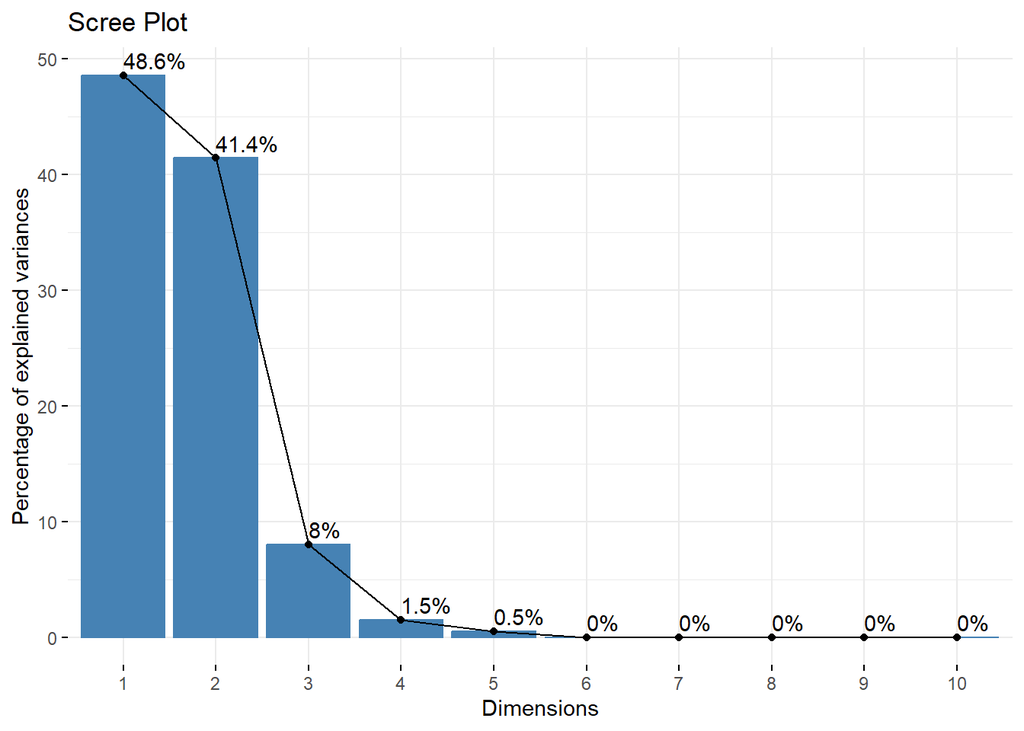

```r
# Scree plot pour visualiser la variance expliquée
fviz_eig(res.pca, addlabels = TRUE, title = "Scree Plot")
```

la coude est au niveau de deuxiéme axe .

Decision: donc on va conserver les deux premiers axes

**Décision finale** : On retient 2 axes.